# String Processing

2022-10-25

## String processing

- One of the most common data wrangling challenges involves extracting numeric data contained in character strings and converting them into the numeric representations required to make plots, compute summaries, or fit models in R.
- Also common is processing unorganized text into meaningful variable names or categorical variables.
- Many of the string processing challenges a data scientist faces are unique and often unexpected.
- It is therefore quite ambitious to write a comprehensive section on this topic.

## String processing

- Here we use a series of case studies that help us demonstrate how string processing is a necessary step for many data wrangling challenges.
- Specifically, we describe the process of converting the not yet shown original *raw* data from which we extracted the `murders`, `heights`, and `research_funding_rates` example into the data frames we have studied in this book.
- By going over these case studies, we will cover some of the most common tasks in string processing including.
- extracting numbers from strings,
- removing unwanted characters from text,
- finding and replacing characters,

## String processing

- extracting specific parts of strings, converting free form text to more uniform formats, and splitting strings into multiple values.
- Base R includes functions to perform all these tasks.
- However, they don’t follow a unifying convention, which makes them a bit hard to memorize and use.
- The **stringr** package basically repackages this functionality, but uses a more consistent approach of naming functions and ordering their arguments.
- For example, in **stringr**, all the string processing functions start with `str_`.

## String processing

- This means that if you type `str_` and hit tab, R will auto-complete and show all the available functions.
- As a result, we don’t necessarily have to memorize all the function names.
- Another advantage is that in the functions in this package the string being processed is always the first argument, which means we can more easily use the pipe.
- Therefore, we will start by describing how to use the functions in the **stringr** package.
- Most of the examples will come from the second case study which deals with self-reported heights by students and most of the chapter is dedicated to learning regular expressions (regex), and functions in the **stringr** package.

## The stringr package

```r
library(tidyverse)
library(stringr)
```

- In general, string processing tasks can be divided into **detecting**, **locating**, **extracting**, or **replacing** patterns in strings.
- We will see several examples.
- The textbook includes a table showing the functions available to you in the **stringr** package.
- We split them by task.
- We also include the R-base equivalent when available.
- All these functions take a character vector as first argument.

## The stringr package

- Also, for each function, operations are vectorized: the operation gets applied to each string in the vector.
- Finally, note that in this table we mention *groups*.
- See table in String Processing chapter in textbook.

## Case study 1: US murders data

- In this section we introduce some of the more simple string processing challenges with the following datasets as an example:

```r
library(rvest)
url <- paste0("https://en.wikipedia.org/w/index.php?title=",
              "Gun_violence_in_the_United_States_by_state",
              "&direction=prev&oldid=810166167")
murders_raw <- read_html(url) |>
  html_node("table") |>
  html_table() |>
  setNames(c("state", "population", "total", "murder_rate"))
```

## Case study 1: US murders data

- The previon code shows the first step in constructing this dataset, from the raw data, which was extracted from a Wikipedia page.

```r
library(dslabs)
data(murders)
```

## Case study 1: US murders data

- In general, string processing involves a string and a pattern.
- In R, we usually store strings in a character vector such as `murders$population`.
- The first three strings in this vector defined by the population variable are:

```r
murders_raw$population[1:3]
```

```
#> [1] "4,853,875" "737,709"   "6,817,565"
```

## Case study 1: US murders data

- The usual coercion does not work here:

```r
as.numeric(murders_raw$population[1:3])
```

- This is because of the commas `,`.

## Case study 1: US murders data

- The string processing we want to do here is remove the **pattern**, `,`, from the **strings** in `murders_raw$population` and then coerce to numbers.
- We can use the `str_detect` function to see that two of the three columns have commas in the entries:

```r
commas <- function(x) any(str_detect(x, ","))
murders_raw |> summarize_all(commas)
```

```
#> # A tibble: 1 × 4
#>   state population total murder_rate
#>   <lgl> <lgl>      <lgl> <lgl>
#> 1 FALSE TRUE       TRUE  FALSE
```

## Case study 1: US murders data

- We can then use the `str_replace_all` function to remove them:

```r
test_1 <- str_replace_all(murders_raw$population, ",", "")
test_1 <- as.numeric(test_1)
```

- We can then use `mutate_all` to apply this operation to each column, since it won’t affect the columns without commas.

## Case study 1: US murders data

- It turns out that this operation is so common that `readr` includes the function `parse_number` specifically meant to remove non-numeric characters before coercing:

```r
test_2 <- parse_number(murders_raw$population)
identical(test_1, test_2)
```

```
#> [1] TRUE
```

## Case study 1: US murders data

- So we can obtain our desired table using:

```r
murders_new <- murders_raw |> mutate_at(2:3, parse_number)
head(murders_new, 4)
```

```
#> # A tibble: 4 × 4
#>   state    population total murder_rate
#>   <chr>         <dbl> <dbl>       <dbl>
#> 1 Alabama     4853875   348         7.2
#> 2 Alaska       737709    59         8
#> 3 Arizona     6817565   309         4.5
#> 4 Arkansas    2977853   181         6.1
```

- This case is relatively simple compared to the string processing challenges that we typically face in data science.
- The next example is a rather complex one and it provides several challenges that will permit us to learn many string processing techniques.

## Case study 2: self-reported heights

- The **dslabs** package includes the raw data from which the heights dataset was obtained.
- You can load it like this:

```r
data(reported_heights)
```

- These heights were obtained using a web form in which students were asked to enter their heights.
- They could enter anything, but the instructions asked for *height in inches*, a number.

## Case study 2: self-reported heights

- We compiled 1,095 submissions, but unfortunately the column vector with the reported heights had several non-numeric entries and as a result became a character vector:

```r
class(reported_heights$height)
```

```
#> [1] "character"
```

## Case study 2: self-reported heights

- If we try to parse it into numbers, we get a warning:

```r
x <- as.numeric(reported_heights$height)
```

```
#> Warning: NAs introduced by coercion
```

- Although most values appear to be height in inches as requested:

```r
head(x)
```

```
#> [1] 75 70 68 74 61 65
```

- we do end up with many `NA`s:

```r
sum(is.na(x))
```

```
#> [1] 81
```

## Case study 2: self-reported heights

- We can see some of the entries that are not successfully converted by using `filter` to keep only the entries resulting in `NA`s:

```r
reported_heights |>
  mutate(new_height = as.numeric(height)) |>
  filter(is.na(new_height)) |>
  head(n=10)
```

```
#>             time_stamp    sex                 height new_height
#> 1  2014-09-02 15:16:28   Male                  5' 4"         NA
#> 2  2014-09-02 15:16:37 Female                  165cm         NA
#> 3  2014-09-02 15:16:52   Male                    5'7         NA
#> 4  2014-09-02 15:16:56   Male                  >9000         NA
#> 5  2014-09-02 15:16:56   Male                   5'7"         NA
#> 6  2014-09-02 15:17:09 Female                   5'3"         NA
#> 7  2014-09-02 15:18:00   Male 5 feet and 8.11 inches         NA
#> 8  2014-09-02 15:19:48   Male                   5'11         NA
#> 9  2014-09-04 00:46:45   Male                  5'9''         NA
#> 10 2014-09-04 10:29:44   Male                 5'10''         NA
```

## Case study 2: self-reported heights

- We immediately see what is happening.
- Some of the students did not report their heights in inches as requested.
- We could discard these data and continue.
- However, many of the entries follow patterns that, in principle, we can easily convert to inches.
- For example, in the output above, we see various cases that use the format `x'y''` with `x` and `y` representing feet and inches, respectively.

## Case study 2: self-reported heights

- Each one of these cases can be read and converted to inches by a human, for example `5'4''` is `5*12 + 4 = 64`.
- So we could fix all the problematic entries *by hand*.
- However, humans are prone to making mistakes, so an automated approach is preferable.
- Also, because we plan on continuing to collect data, it will be convenient to write code that automatically does this.
- A first step in this type of task is to survey the problematic entries and try to define specific patterns followed by a large groups of entries.
- The larger these groups, the more entries we can fix with a single programmatic approach.

## Case study 2: self-reported heights

- We want to find patterns that can be accurately described with a rule, such as “a digit, followed by a feet symbol, followed by one or two digits, followed by an inches symbol”.
- To look for such patterns, it helps to remove the entries that are consistent with being in inches and to view only the problematic entries.
- We thus write a function to automatically do this.
- We keep entries that either result in `NA`s when applying `as.numeric` or are outside a range of plausible heights.
- We permit a range that covers about 99.9999% of the adult population.

## Case study 2: self-reported heights

- We also use `suppressWarnings` to avoid the warning message we know `as.numeric` will gives us.

```r
not_inches <- function(x, smallest = 50, tallest = 84){
  inches <- suppressWarnings(as.numeric(x))
  ind <- is.na(inches) | inches < smallest | inches > tallest
  ind
}
```

## Case study 2: self-reported heights

- We apply this function and find the number of problematic entries:

```r
problems <- reported_heights |>
  filter(not_inches(height)) |>
  pull(height)
length(problems)
```

```
#> [1] 292
```

## Case study 2: self-reported heights

- We can now view all the cases by simply printing them.
- We don’t do that here because there are `length(problems)`, but after surveying them carefully, we see that three patterns can be used to define three large groups within these exceptions.
- A pattern of the form `x'y` or `x' y''` or `x'y"` with `x` and `y` representing feet and inches, respectively.

## Case study 2: self-reported heights

- Here are ten examples:

```
#> 5' 4" 5'7 5'7" 5'3" 5'11 5'9'' 5'10'' 5' 10 5'5" 5'2"
```

## Case study 2: self-reported heights

- A pattern of the form `x.y` or `x,y` with `x` feet and `y` inches.
- Here are ten examples:

```
#> 5.3 5.5 6.5 5.8 5.6 5,3 5.9 6,8 5.5 6.2
```

## Case study 2: self-reported heights

- Entries that were reported in centimeters rather than inches.
- Here are ten examples:

```
#> 150 175 177 178 163 175 178 165 165 180
```

## Case study 2: self-reported heights

- Once we see these large groups following specific patterns, we can develop a plan of attack.
- Remember that there is rarely just one way to perform these tasks.
- Here we pick one that helps us teach several useful techniques.
- But surely there is a more efficient way of performing the task.
- **Plan of attack**: we will convert entries fitting the first two patterns into a standardized one.

## Case study 2: self-reported heights

- We will then leverage the standardization to extract the feet and inches and convert to inches.
- We will then define a procedure for identifying entries that are in centimeters and convert them to inches.
- After applying these steps, we will then check again to see what entries were not fixed and see if we can tweak our approach to be more comprehensive.
- At the end, we hope to have a script that makes web-based data collection methods robust to the most common user mistakes.
- To achieve our goal, we will use a technique that enables us to accurately detect patterns and extract the parts we want: *regular expressions* (regex).

## Case study 2: self-reported heights

- But first, we quickly describe how to *escape* the function of certain characters so that they can be included in strings.

## How to *escape* when defining strings

- To define strings in R, we can use either double quotes:

```r
s <- "Hello!"
```

- or single quotes:

```r
s <- 'Hello!'
```

- Make sure you choose the correct single quote since using the back quote will give you an error:

```r
s <- `Hello`
```

```
Error: object 'Hello' not found
```

## How to *escape* when defining strings

- Now, what happens if the string we want to define includes double quotes? For example, if we want to write 10 inches like this `10"`?
- In this case you can’t use:

```r
s <- "10""
```

- because this is just the string `10` followed by a double quote.

## How to *escape* when defining strings

- If you type this into R, you get an error because you have an *unclosed* double quote.
- To avoid this, we can use the single quotes:

```r
s <- '10"'
```

- If we print out `s` we see that the double quotes are *escaped* with the backslash `\`.

```r
s
```

```
#> [1] "10\""
```

## How to *escape* when defining strings

- In fact, escaping with the backslash provides a way to define the string while still using the double quotes to define strings:

```r
s <- "10\""
```

- In R, the function `cat` lets us see what the string actually looks like:

```r
cat(s)
```

```
#> 10"
```

## How to *escape* when defining strings

- Now, what if we want our string to be 5 feet written like this `5'`? In this case, we can use the double quotes:

```r
s <- "5'"
cat(s)
```

```
#> 5'
```

## How to *escape* when defining strings

- So we’ve learned how to write 5 feet and 10 inches separately, but what if we want to write them together to represent *5 feet and 10 inches* like this `5'10"`? In this case, neither the single nor double quotes will work.
- This:

```r
s <- '5'10"'
```

- closes the string after 5 and this:

```r
s <- "5'10""
```

- closes the string after 10.

## How to *escape* when defining strings

- Keep in mind that if we type one of the above code snippets into R, it will get stuck waiting for you to close the open quote and you will have to exit the execution with the *esc* button.
- In this situation, we need to escape the function of the quotes with the backslash `\`.

## How to *escape* when defining strings

- You can escape either character like this:

```r
s <- '5\'10"'
cat(s)
```

```
#> 5'10"
```

- or like this:

```r
s <- "5'10\""
cat(s)
```

```
#> 5'10"
```

- Escaping characters is something we often have to use when processing strings.

## Regular expressions

- A regular expression (regex) is a way to describe specific patterns of characters of text.
- They can be used to determine if a given string matches the pattern.
- A set of rules has been defined to do this efficiently and precisely and here we show some examples.
- We can learn more about these rules by reading a [detailed tutorials](https://www.regular-expressions.info/tutorial.html).
- This RStudio [cheat sheet](https://www.rstudio.com/wp-content/uploads/2016/09/RegExCheatsheet.pdf) is also very useful.

## Regular expressions

- The patterns supplied to the **stringr** functions can be a regex rather than a standard string.
- We will learn how this works through a series of examples.
- Throughout this section you will see that we create strings to test out our regex.
- To do this, we define patterns that we know should match and also patterns that we know should not.
- We will call them `yes` and `no`, respectively.
- This permits us to check for the two types of errors: failing to match and incorrectly matching.

## Strings are a regexp

- Technically any string is a regex, perhaps the simplest example is a single character.
- So the comma `,` used in the next code example is a simple example of searching with regex.

```r
pattern <- ","
str_detect(murders_raw$total, pattern)
```

## Strings are a regexp

- We suppress the output which is logical vector telling us which entries have commas.
- Above, we noted that an entry included a `cm`.
- This is also a simple example of a regex.
- We can show all the entries that used `cm` like this:

## Strings are a regexp

```r
str_subset(reported_heights$height, "cm")
```

```
#> [1] "165cm"  "170 cm"
```

## Special characters

- Now let’s consider a slightly more complicated example.
- Which of the following strings contain the pattern `cm` or `inches`?

```r
yes <- c("180 cm", "70 inches")
no <- c("180", "70''")
s <- c(yes, no)
```

```r
str_detect(s, "cm") | str_detect(s, "inches")
```

```
#> [1]  TRUE  TRUE FALSE FALSE
```

## Strings are a regexp

- However, we don’t need to do this.
- The main feature that distinguishes the regex *language* from plain strings is that we can use special characters.
- These are characters with a meaning.
- We start by introducing `|` which means *or*.

## Special characters

- So if we want to know if either `cm` or `inches` appears in the strings, we can use the regex `cm|inches`:

```r
str_detect(s, "cm|inches")
```

```
#> [1]  TRUE  TRUE FALSE FALSE
```

- and obtain the correct answer.

## Strings are a regexp

- Another special character that will be useful for identifying feet and inches values is `\d` which means any digit: 0, 1, 2, 3, 4, 5, 6, 7, 8, 9.
- The backslash is used to distinguish it from the character `d`.
- In R, we have to *escape* the backslash `\` so we actually have to use `\\d` to represent digits.

## Strings are a regexp

- Here is an example:

```r
yes <- c("5", "6", "5'10", "5 feet", "4'11")
no <- c("", ".", "Five", "six")
s <- c(yes, no)
pattern <- "\\d"
str_detect(s, pattern)
```

```
#> [1]  TRUE  TRUE  TRUE  TRUE  TRUE FALSE FALSE FALSE FALSE
```

## Strings are a regexp

- We take this opportunity to introduce the `str_view` function, which is helpful for troubleshooting as it shows us the first match for each string:

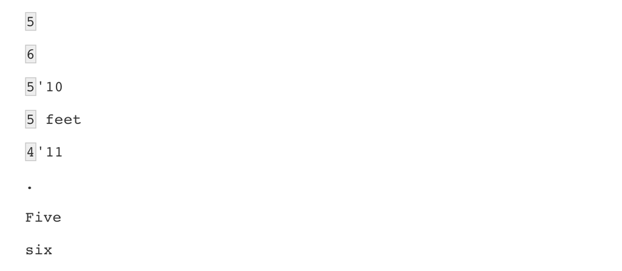

```r
str_view(s, pattern)
```

## Strings are a regexp

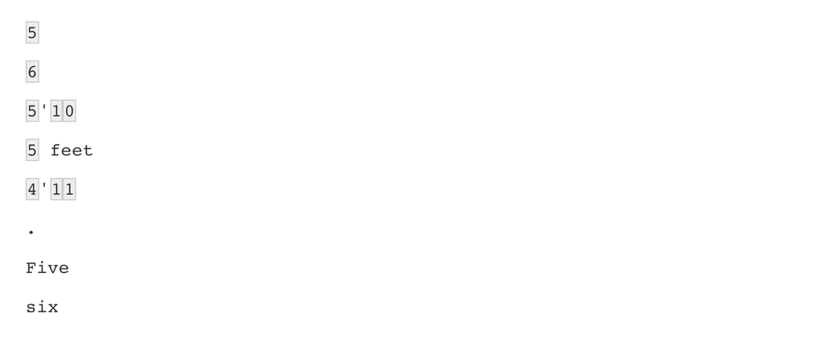

```r
str_view_all(s, pattern)
```

- There are many other special characters.

## Special characters

- We will learn some others below, but you can see most or all of them in the [cheat sheet](https://www.rstudio.com/wp-content/uploads/2016/09/RegExCheatsheet.pdf) mentioned earlier.
- Finally, a useful special character is `\w` which stands for *word character* and it matches any letter, number, or underscore.
- It is equivalent to `[a-zA-Z0-9_]`.

## Character classes

- Character classes are used to define a series of characters that can be matched.
- We define character classes with square brackets `[]`.
- So, for example, if we want the pattern to match only if we have a `5` or a `6`, we use the regex `[56]`:

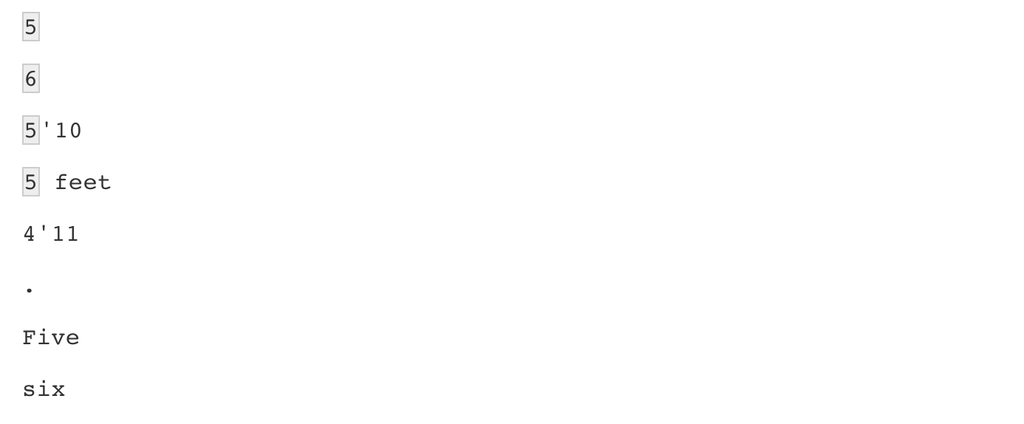

```r
str_view(s, "[56]")
```

- Suppose we want to match values between 4 and 7.
- A common way to define character classes is with ranges.
- So, for example, `[0-9]` is equivalent to `\\d`.
- The pattern we want is therefore `[4-7]`.

## Character classes

```r
yes <- as.character(4:7)
no <- as.character(1:3)
s <- c(yes, no)
str_detect(s, "[4-7]")
```

```
#> [1]  TRUE  TRUE  TRUE  TRUE FALSE FALSE FALSE
```

- However, it is important to know that in regex everything is a character; there are no numbers.
- So `4` is the character `4` not the number four.
- Notice, for example, that `[1-20]` does **not** mean 1 through 20, it means the characters 1 through 2 or the character 0.
- So `[1-20]` simply means the character class composed of 0, 1, and 2.

## Character classes

- Keep in mind that characters do have an order and the digits do follow the numeric order.
- So `0` comes before `1` which comes before `2` and so on.
- For the same reason, we can define lower case letters as `[a-z]`, upper case letters as `[A-Z]`, and `[a-zA-z]` as both.

## Anchors

- What if we want a match when we have exactly 1 digit? This will be useful in our case study since feet are never more than 1 digit so a restriction will help us.
- One way to do this with regex is by using *anchors*, which let us define patterns that must start or end at a specific place.
- The two most common anchors are.
- `^` and `$` which represent the beginning and end of a string, respectively.
- So the pattern `^\\d$` is read as “start of the string followed by one digit followed by end of string”.

## Anchors

- This pattern only detects the strings with exactly one digit:

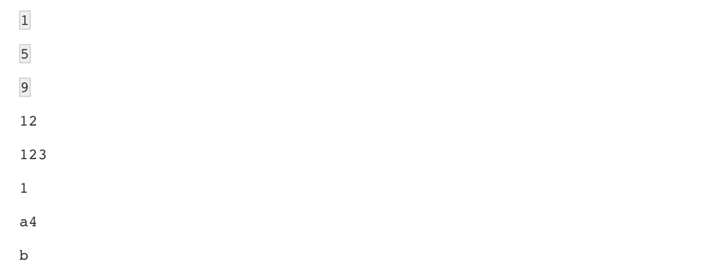

```r
pattern <- "^\\d$"
yes <- c("1", "5", "9")
no <- c("12", "123", " 1", "a4", "b")
s <- c(yes, no)
str_view_all(s, pattern)
```

- The `1` does not match because it does not start with the digit but rather with a space, which is actually not easy to see.

## Quantifiers

- For the inches part, we can have one or two digits.
- This can be specified in regex with *quantifiers*.
- This is done by following the pattern with curly brackets containing the number of times the previous entry can be repeated.
- We use an example to illustrate.

## Quantifiers

- The pattern for one or two digits is:

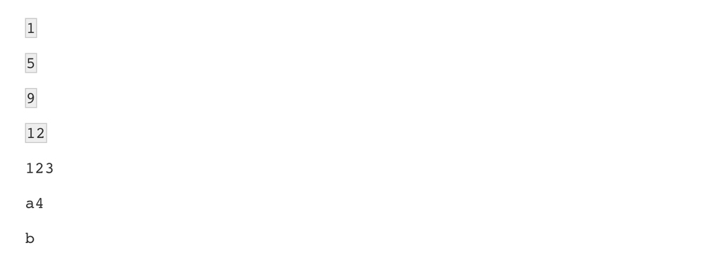

```r
pattern <- "^\\d{1,2}$"
yes <- c("1", "5", "9", "12")
no <- c("123", "a4", "b")
str_view(c(yes, no), pattern)
```

## Quantifiers

- In this case, `123` does **not** match, but `12` does.
- So to look for our feet and inches pattern, we can add the symbols for feet `'` and inches `"` after the digits.
- With what we have learned, we can now construct an example for the pattern `x'y\"` with `x` feet and `y` inches.

```r
pattern <- "^[4-7]'\\d{1,2}\"$"
```

## Quantifiers

- The pattern is now getting complex, but you can look at it carefully and break it down:
- `^` = start of the string.
- `[4-7]` = one digit, either 4,5,6 or 7.
- `'` = feet symbol.
- `\\d{1,2}` = one or two digits.
- `\"` = inches symbol.
- `$` = end of the string.

## Quantifiers

- Let’s test it out:

```r
pattern <- "^[4-7]'\\d{1,2}\"$"
yes <- c("5'7\"", "6'2\"",  "5'12\"")
no <- c("6,2\"", "6.2\"","I am 5'11\"", "3'2\"", "64")
str_detect(yes, pattern)
```

```
#> [1] TRUE TRUE TRUE
```

```r
str_detect(no, pattern)
```

```
#> [1] FALSE FALSE FALSE FALSE FALSE
```

## Quantifiers

- For now, we are permitting the inches to be 12 or larger.
- We will add a restriction later as the regex for this is a bit more complex than we are ready to show.

## White space `\s`

- Another problem we have are spaces.
- For example, our pattern does not match `5' 4"` because there is a space between `'` and `4` which our pattern does not permit.

## White space `\s`

- Spaces are characters and R does not ignore them:

```r
identical("Hi", "Hi ")
```

```
#> [1] FALSE
```

## White space `\s`

- In regex, `\s` represents white space.
- To find patterns like `5' 4`, we can change our pattern to:

```r
pattern_2 <- "^[4-7]'\\s\\d{1,2}\"$"
str_subset(problems, pattern_2)
```

```
#> [1] "5' 4\""  "5' 11\"" "5' 7\""
```

- However, this will not match the patterns with no space.
- So do we need more than one regex pattern? It turns out we can use a quantifier for this as well.

## Quantifiers: `*`, `?`, `+`

- We want the pattern to permit spaces but not require them.
- Even if there are several spaces, like in this example `5' 4`, we still want it to match.
- There is a quantifier for exactly this purpose.
- In regex, the character `*` means zero or more instances of the previous character.

## Quantifiers: `*`, `?`, `+`

- Here is an example:

```r
yes <- c("AB", "A1B", "A11B", "A111B", "A1111B")
no <- c("A2B", "A21B")
str_detect(yes, "A1*B")
```

```
#> [1] TRUE TRUE TRUE TRUE TRUE
```

```r
str_detect(no, "A1*B")
```

```
#> [1] FALSE FALSE
```

## Quantifiers: `*`, `?`, `+`

- The above matches the first string which has zero 1s and all the strings with one or more 1.
- We can then improve our pattern by adding the `*` after the space character `\s`.
- There are two other similar quantifiers.
- For none or once, we can use `?`, and for one or more, we can use `+`.

## Quantifiers: `*`, `?`, `+`

- You can see how they differ with this example:

```r
data.frame(string = c("AB", "A1B", "A11B", "A111B", "A1111B"),
           none_or_more = str_detect(yes, "A1*B"),
           nore_or_once = str_detect(yes, "A1?B"),
           once_or_more = str_detect(yes, "A1+B"))
```

```
#>   string none_or_more nore_or_once once_or_more
#> 1     AB         TRUE         TRUE        FALSE
#> 2    A1B         TRUE         TRUE         TRUE
#> 3   A11B         TRUE        FALSE         TRUE
#> 4  A111B         TRUE        FALSE         TRUE
#> 5 A1111B         TRUE        FALSE         TRUE
```

## Quantifiers: `*`, `?`, `+`

- We will actually use all three in our reported heights example, but we will see these in a later section.

## Not

- To specify patterns that we do **not** want to detect, we can use the `^` symbol but only **inside** square brackets.
- Remember that outside the square bracket `^` means the start of the string.
- So, for example, if we want to detect digits that are preceded by anything except a letter we can do the following:

```r
pattern <- "[^a-zA-Z]\\d"
yes <- c(".3", "+2", "-0","*4")
no <- c("A3", "B2", "C0", "E4")
str_detect(yes, pattern)
```

```
#> [1] TRUE TRUE TRUE TRUE
```

```r
str_detect(no, pattern)
```

```
#> [1] FALSE FALSE FALSE FALSE
```

## Not

- Another way to generate a pattern that searches for *everything except* is to use the upper case of the special character.
- For example `\\D` means anything other than a digit, `\\S` means anything except a space, and so on.

## Lookarounds

- Lookarounds provide a way to ask for one or more conditions to be satisfied without moving the search forward or matching it.
- For example, you might want to check for multiple conditions and if they are matched, then return the pattern or part of the pattern that matched.
- An example: check if a string satisfies the conditions for a password and if it does return the password.
- Suppose the conditions are 1) 8-16 word characters, 2) starts with a letter, and 3) has at least one digit.
- There are four types of lookarounds: lookahead `(?=pattern)`, lookbehind `(?<=pattern)`, negative lookahead `(?!pattern)`, and negative lookbehind `(?<!pattern)`.

## Lookarounds

- You can concatenate them to check for multiple conditions so for our example we can write it like this:

```r
pattern <- "(?=\\w{8,16})(?=^[a-z|A-Z].*)(?=.*\\d+.*).*"
yes <- c("Ihatepasswords1", "password1234")
no <- c("sh0rt", "Ihaterpasswords", "7X%9,N`yrYG92b7")
str_detect(yes, pattern)
```

```
#> [1] TRUE TRUE
```

```r
str_detect(no, pattern)
```

```
#> [1] FALSE FALSE FALSE
```

```r
str_extract(yes, pattern)
```

```
#> [1] "Ihatepasswords1" "password1234"
```

## Groups

- *Groups* are a powerful aspect of regex that permits the extraction of values.
- Groups are defined using parentheses.
- They don’t affect the pattern matching per se.
- Instead, it permits tools to identify specific parts of the pattern so we can extract them.

## Groups

- We want to change heights written like `5.6` to `5'6`.
- To avoid changing patterns such as `70.2`, we will require that the first digit be between 4 and 7 `[4-7]` and that the second be none or more digits `\\d*`.
- Let’s start by defining a simple pattern that matches this:

## Groups

```r
pattern_without_groups <- "^[4-7],\\d*$"
```

- We want to extract the digits so we can then form the new version using a period.
- These are our two groups, so we encapsulate them with parentheses:

```r
pattern_with_groups <-  "^([4-7]),(\\d*)$"
```

## Groups

- We encapsulate the part of the pattern that matches the parts we want to keep for later use.
- Adding groups does not affect the detection, since it only signals that we want to save what is captured by the groups.
- Note that both patterns return the same result when using `str_detect`:

## Groups

```r
yes <- c("5,9", "5,11", "6,", "6,1")
no <- c("5'9", ",", "2,8", "6.1.1")
s <- c(yes, no)
str_detect(s, pattern_without_groups)
```

```
#> [1]  TRUE  TRUE  TRUE  TRUE FALSE FALSE FALSE FALSE
```

```r
str_detect(s, pattern_with_groups)
```

```
#> [1]  TRUE  TRUE  TRUE  TRUE FALSE FALSE FALSE FALSE
```

## Groups

- Once we define groups, we can use the function `str_match` to extract the values these groups define:

```r
str_match(s, pattern_with_groups)
```

```
#>      [,1]   [,2] [,3]
#> [1,] "5,9"  "5"  "9"
#> [2,] "5,11" "5"  "11"
#> [3,] "6,"   "6"  ""
#> [4,] "6,1"  "6"  "1"
#> [5,] NA     NA   NA
#> [6,] NA     NA   NA
#> [7,] NA     NA   NA
#> [8,] NA     NA   NA
```

- Notice that the second and third columns contain feet and inches, respectively. The first column is the part of the string matching the pattern.

## Groups

- Once we define groups, we can use the function `str_match` to extract the values these groups define:

```r
str_match(s, pattern_with_groups)
```

```
#>      [,1]   [,2] [,3]
#> [1,] "5,9"  "5"  "9"
#> [2,] "5,11" "5"  "11"
#> [3,] "6,"   "6"  ""
#> [4,] "6,1"  "6"  "1"
#> [5,] NA     NA   NA
#> [6,] NA     NA   NA
#> [7,] NA     NA   NA
#> [8,] NA     NA   NA
```

- If no match occurred, we see an `NA`.

## Groups

- Now we can understand the difference between the functions `str_extract` and `str_match`: `str_extract` extracts only strings that match a pattern, not the values defined by groups:

```r
str_extract(s, pattern_with_groups)
```

```
#> [1] "5,9"  "5,11" "6,"   "6,1"  NA     NA     NA     NA
```

## Search and replace with regex

- Earlier we defined the object `problems` containing the strings that do not appear to be in inches.
- We can see that not too many of our problematic strings match the pattern:

```r
pattern <- "^[4-7]'\\d{1,2}\"$"
sum(str_detect(problems, pattern))
```

```
#> [1] 14
```

## Search and replace with regex

- To see why this is, we show some examples that expose why we don’t have more matches:

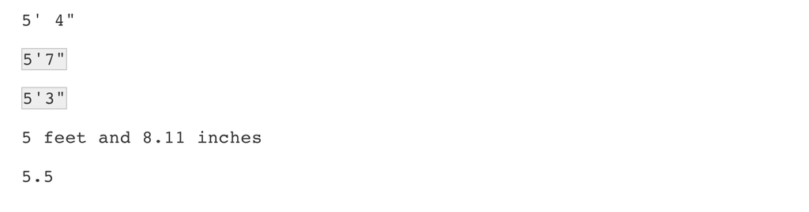

```r
problems[c(2, 10, 11, 12, 15)] |> str_view(pattern)
```

## Search and replace with regex

- An initial problem we see immediately is that some students wrote out the words “feet” and “inches”.
- We can see the entries that did this with the `str_subset` function:

```r
str_subset(problems, "inches")
```

```
#> [1] "5 feet and 8.11 inches" "Five foot eight inches" "5 feet 7inches"
#> [4] "5ft 9 inches"           "5 ft 9 inches"          "5 feet 6 inches"
```

## Search and replace with regex

- We also see that some entries used two single quotes `''` instead of a double quote `"`.

```r
str_subset(problems, "''")
```

```
#>  [1] "5'9''"   "5'10''"  "5'10''"  "5'3''"   "5'7''"   "5'6''"   "5'7.5''"
#>  [8] "5'7.5''" "5'10''"  "5'11''"  "5'10''"  "5'5''"
```

- To correct this, we can replace the different ways of representing inches and feet with a uniform symbol.

## Search and replace with regex

- We will use `'` for feet, whereas for inches we will simply not use a symbol since some entries were of the form `x'y`.
- Now, if we no longer use the inches symbol, we have to change our pattern accordingly:

## Search and replace with regex

```r
pattern <- "^[4-7]'\\d{1,2}$"
```

- If we do this replacement before the matching, we get many more matches:

```r
problems |>
  str_replace("feet|ft|foot", "'") |> # replace feet, ft, foot with '
  str_replace("inches|in|''|\"", "") |> # remove all inches symbols
  str_detect(pattern) |>
  sum()
```

```
#> [1] 48
```

## Search and replace with regex

- However, we still have many cases to go.
- Note that in the code above, we leveraged the **stringr** consistency and used the pipe.
- For now, we improve our pattern by adding `\\s*` in front of and after the feet symbol `'` to permit space between the feet symbol and the numbers.

## Search and replace with regex

- Now we match a few more entries:

```r
pattern <- "^[4-7]\\s*'\\s*\\d{1,2}$"
problems |>
  str_replace("feet|ft|foot", "'") |> # replace feet, ft, foot with '
  str_replace("inches|in|''|\"", "") |> # remove all inches symbols
  str_detect(pattern) |>
  sum()
```

```
#> [1] 53
```

## Search and replace with regex

- We might be tempted to avoid doing this by removing all the spaces with `str_replace_all`.
- However, when doing such an operation we need to make sure that it does not have unintended effects.
- In our reported heights examples, this will be a problem because some entries are of the form `x y` with space separating the feet from the inches.

## Search and replace with regex

- If we remove all spaces, we will incorrectly turn `x y` into `xy` which implies that a `6 1` would become `61` inches instead of `73` inches.
- The second large type of problematic entries were of the form `x.y`, `x,y` and `x y`.
- We want to change all these to our common format `x'y`.
- But we can’t just do a search and replace because we would change values such as `70.5` into `70'5`.
- Our strategy will therefore be to search for a very specific pattern that assures us feet and inches are being provided and then, for those that match, replace appropriately.

## Search and replace using groups

- Another powerful aspect of groups is that you can refer to the extracted values in a regex when searching and replacing.
- The regex special character for the `i`-th group is `\\i`.
- So `\\1` is the value extracted from the first group, `\\2` the value from the second and so on.

## Search and replace with regex

- As a simple example, note that the following code will replace a comma with period, but only if it is between two digits:

```r
pattern_with_groups <-  "^([4-7]),(\\d*)$"
yes <- c("5,9", "5,11", "6,", "6,1")
no <- c("5'9", ",", "2,8", "6.1.1")
s <- c(yes, no)
str_replace(s, pattern_with_groups, "\\1'\\2")
```

```
#> [1] "5'9"   "5'11"  "6'"    "6'1"   "5'9"   ","     "2,8"   "6.1.1"
```

## Search and replace using groups

- We can use this to convert cases in our reported heights.
- We are now ready to define a pattern that helps us convert all the `x.y`, `x,y` and `x y` to our preferred format.

## Search and replace with regex

- We need to adapt `pattern_with_groups` to be a bit more flexible and capture all the cases.

```r
pattern_with_groups <-"^([4-7])\\s*[,\\.\\s+]\\s*(\\d*)$"
```

- Let’s break this one down:
- `^` = start of the string.
- `[4-7]` = one digit, either 4, 5, 6, or 7.
- `\\s*` = none or more white space.
- `[,\\.\\s+]` = feet symbol is either `,`, `.` or at least one space.
- `\\s*` = none or more white space.
- `\\d*` = none or more digits.
- `$` = end of the string.
- We can see that it appears to be working:

## Search and replace using groups

```r
str_subset(problems, pattern_with_groups) |> head()
```

```
#> [1] "5.3"  "5.25" "5.5"  "6.5"  "5.8"  "5.6"
```

- and will be able to perform the search and replace:

```r
str_subset(problems, pattern_with_groups) |>
  str_replace(pattern_with_groups, "\\1'\\2") |> head()
```

```
#> [1] "5'3"  "5'25" "5'5"  "6'5"  "5'8"  "5'6"
```

- Again, we will deal with the inches-larger-than-twelve challenge later.

## Testing and improving

- Developing the right regex on the first try is often difficult.
- Trial and error is a common approach to finding the regex pattern that satisfies all desired conditions.
- In the previous sections, we have developed a powerful string processing technique that can help us catch many of the problematic entries.
- Here we will test our approach, search for further problems, and tweak our approach for possible improvements.

## Testing and improving

- Let’s write a function that captures all the entries that can’t be converted into numbers remembering that some are in centimeters (we will deal with those later):

```r
not_inches_or_cm <- function(x, smallest = 50, tallest = 84){
  inches <- suppressWarnings(as.numeric(x))
  ind <- !is.na(inches) &
    ((inches >= smallest & inches <= tallest) |
       (inches/2.54 >= smallest & inches/2.54 <= tallest))
  !ind
}
problems <- reported_heights |>
  filter(not_inches_or_cm(height)) |>
  pull(height)
length(problems)
```

```
#> [1] 200
```

## Testing and improving

- Let’s see what proportion of these fit our pattern after the processing steps we developed above:

```r
converted <- problems |>
  str_replace("feet|foot|ft", "'") |> # convert feet symbols to '
  str_replace("inches|in|''|\"", "") |>  # remove inches symbols
  str_replace("^([4-7])\\s*[,\\.\\s+]\\s*(\\d*)$", "\\1'\\2")# change format
pattern <- "^[4-7]\\s*'\\s*\\d{1,2}$"
index <- str_detect(converted, pattern)
mean(index)
```

```
#> [1] 0.615
```

## Testing and improving

- Note how we leveraged the pipe, one of the advantages of using **stringr**.
- This last piece of code shows that we have matched well over half of the strings.

## Testing and improving

- Let’s examine the remaining cases:

```r
converted[!index]
```

```
#>  [1] "6"             "165cm"         "511"           "6"
#>  [5] "2"             ">9000"         "5 ' and 8.11 " "11111"
#>  [9] "6"             "103.2"         "19"            "5"
#> [13] "300"           "6'"            "6"             "Five ' eight "
#> [17] "7"             "214"           "6"             "0.7"
#> [21] "6"             "2'33"          "612"           "1,70"
#> [25] "87"            "5'7.5"         "5'7.5"         "111"
#> [29] "5' 7.78"       "12"            "6"             "yyy"
#> [33] "89"            "34"            "25"            "6"
#> [37] "6"             "22"            "684"           "6"
#> [41] "1"             "1"             "6*12"          "87"
#> [45] "6"             "1.6"           "120"           "120"
#> [49] "23"            "1.7"           "6"             "5"
#> [53] "69"            "5' 9 "         "5 ' 9 "        "6"
#> [57] "6"             "86"            "708,661"       "5 ' 6 "
#> [61] "6"             "649,606"       "10000"         "1"
#> [65] "728,346"       "0"             "6"             "6"
#> [69] "6"             "100"           "88"            "6"
#> [73] "170 cm"        "7,283,465"     "5"             "5"
#> [77] "34"
```

## Testing and improving

- Four clear patterns arise:
- Many students measuring exactly 5 or 6 feet did not enter any inches, for example `6'`, and our pattern requires that inches be included.
- Some students measuring exactly 5 or 6 feet entered just that number.
- Some of the inches were entered with decimal points.
- For example `5'7.5''`.

## Testing and improving

- Our pattern only looks for two digits.
- Some entries have spaces at the end, for example `5 ' 9`.
- Although not as common, we also see the following problems:
- Some entries are in meters and some of these use European decimals: `1.6`, `1,70`.
- Two students added `cm`.

## Testing and improving

- A student spelled out the numbers: `Five foot eight inches`.
- It is not necessarily clear that it is worth writing code to handle these last three cases since they might be rare enough.
- However, some of them provide us with an opportunity to learn a few more regex techniques, so we will build a fix.
- For case 1, if we add a `'0` after the first digit, for example, convert all `6` to `6'0`, then our previously defined pattern will match.

## Testing and improving

- This can be done using groups:

```r
yes <- c("5", "6", "5")
no <- c("5'", "5''", "5'4")
s <- c(yes, no)
str_replace(s, "^([4-7])$", "\\1'0")
```

```
#> [1] "5'0" "6'0" "5'0" "5'"  "5''" "5'4"
```

## Testing and improving

- The pattern says it has to start (`^`) with a digit between 4 and 7 and end there (`$`).
- The parenthesis defines the group that we pass as `\\1` to generate the replacement regex string.
- We can adapt this code slightly to handle the case 2 as well, which covers the entry `5'`.
- Note `5'` is left untouched.
- This is because the extra `'` makes the pattern not match since we have to end with a 5 or 6.

## Testing and improving

- We want to permit the 5 or 6 to be followed by 0 or 1 feet sign.
- So we can simply add `'{0,1}` after the `'` to do this.
- However, we can use the none or once special character `?`.
- As we saw above, this is different from `*` which is none or more.

## Testing and improving

- We now see that the fourth case is also converted:

```r
str_replace(s, "^([56])'?$", "\\1'0")
```

```
#> [1] "5'0" "6'0" "5'0" "5'0" "5''" "5'4"
```

- Here we only permit 5 and 6, but not 4 and 7.
- This is because 5 and 6 feet tall is quite common, so we assume those that typed 5 or 6 really meant `60` or `72` inches.

## Testing and improving

- However, `4` and `7` feet tall are so rare that, although we accept `84` as a valid entry, we assume `7` was entered in error.
- We can use quantifiers to deal with **case 3**.
- These entries are not matched because the inches include decimals and our pattern does not permit this.

## Testing and improving

- We need to allow the second group to include decimals not just digits.
- This means we must permit zero or one period `.` then zero or more digits.
- So we will be using both `?` and `*`.

## Testing and improving

- Also remember that, for this particular case, the period needs to be escaped since it is a special character (it means any character except line break).
- Here is a simple example of how we can use `*`.
- So we can adapt our pattern, currently `^[4-7]\\s*'\\s*\\d{1,2}$` to permit a decimal at the end:

```r
pattern <- "^[4-7]\\s*'\\s*(\\d+\\.?\\d*)$"
```

## Testing and improving

- Case 4, meters using commas, we can approach similarly to how we converted the `x.y` to `x'y`.
- A difference is that we require that the first digit be 1 or 2:

```r
yes <- c("1,7", "1, 8", "2, " )
no <- c("5,8", "5,3,2", "1.7")
s <- c(yes, no)
str_replace(s, "^([12])\\s*,\\s*(\\d*)$", "\\1\\.\\2")
```

```
#> [1] "1.7"   "1.8"   "2."    "5,8"   "5,3,2" "1.7"
```

## Testing and improving

- We will later check if the entries are meters using their numeric values.
- We will come back to the case study after introducing two widely used functions in string processing that will come in handy when developing our final solution for the self-reported heights.

## Trimming

- In general, spaces at the start or end of the string are uninformative.
- These can be particularly deceptive because sometimes they can be hard to see:

```r
s <- "Hi "
cat(s)
```

```
#> Hi
```

```r
identical(s, "Hi")
```

```
#> [1] FALSE
```

## Trimming

- This is a general enough problem that there is a function dedicated to removing them:
- `str_trim`.

```r
str_trim("5 ' 9 ")
```

```
#> [1] "5 ' 9"
```

## Changing lettercase

- Notice that regex is case sensitive.
- Often we want to match a word regardless of case.
- One approach to doing this is to first change everything to lower case and then proceeding ignoring case.

## Changing lettercase

- To avoid having to write two separate operations for `Zero` and `zero`, `One` and `one`, etc., we can use the `str_to_lower` function to make all works lower case first:

```r
s <- c("Five feet eight inches")
str_to_lower(s)
```

```
#> [1] "five feet eight inches"
```

## Changing lettercase

- Other related functions are `str_to_upper` and `str_to_title`.
- We are now ready to define a procedure that converts all the problematic cases to inches.

## Case study 2: self-reported heights

- We now put all of what we have learned together into a function that takes a string vector and tries to convert as many strings as possible to one format.
- We write a function that puts together what we have done above.

```r
convert_format <- function(s){
  s |>
    str_replace("feet|foot|ft", "'") |>
    str_replace_all("inches|in|''|\"|cm|and", "") |>
    str_replace("^([4-7])\\s*[,\\.\\s+]\\s*(\\d*)$", "\\1'\\2") |>
    str_replace("^([56])'?$", "\\1'0") |>
    str_replace("^([12])\\s*,\\s*(\\d*)$", "\\1\\.\\2") |>
    str_trim()
}
```

## Case study 2: self-reported heights

- We can also write a function that converts words to numbers:

```r
library(english)
words_to_numbers <- function(s){
  s <- str_to_lower(s)
  for(i in 0:11)
    s <- str_replace_all(s, words(i), as.character(i))
  s
}
```

- Note that we can perform the above operation more efficiently with the function `recode`, which we learn about later.

## Case study 2: self-reported heights

- Now we can see which problematic entries remain:

```r
converted <- problems |> words_to_numbers() |> convert_format()
remaining_problems <- converted[not_inches_or_cm(converted)]
pattern <- "^[4-7]\\s*'\\s*\\d+\\.?\\d*$"
index <- str_detect(remaining_problems, pattern)
remaining_problems[!index]
```

```
#>  [1] "511"       "2"         ">9000"     "11111"     "103.2"     "19"
#>  [7] "300"       "7"         "214"       "0.7"       "2'33"      "612"
#> [13] "1.70"      "87"        "111"       "12"        "yyy"       "89"
#> [19] "34"        "25"        "22"        "684"       "1"         "1"
#> [25] "6*12"      "87"        "1.6"       "120"       "120"       "23"
#> [31] "1.7"       "86"        "708,661"   "649,606"   "10000"     "1"
#> [37] "728,346"   "0"         "100"       "88"        "7,283,465" "34"
```

- apart from the cases reported as meters, which we will fix below, they all seem to be cases that are impossible to fix.

## The `extract` function

- The `extract` function is a useful **tidyverse** function for string processing that we will use in our final solution, so we introduce it here.
- In a previous section, we constructed a regex that lets us identify which elements of a character vector match the feet and inches pattern.
- However, we want to do more.
- We want to extract and save the feet and number values so that we can convert them to inches when appropriate.

## The `extract` function

- If we have a simpler case like this:

```r
s <- c("5'10", "6'1")
tab <- data.frame(x = s)
```

## The `extract` function

- We learned about the `separate` function, which can be used to achieve our current goal:

```r
tab |> separate(x, c("feet", "inches"), sep = "'")
```

```
#>   feet inches
#> 1    5     10
#> 2    6      1
```

- The `extract` function from the **tidyr** package lets us use regex groups to extract the desired values.

## The `extract` function

- Here is the equivalent to the code above using `separate` but using `extract`:

```r
library(tidyr)
tab |> extract(x, c("feet", "inches"), regex = "(\\d)'(\\d{1,2})")
```

```
#>   feet inches
#> 1    5     10
#> 2    6      1
```

- So why do we even need the new function `extract`? We have seen how small changes can throw off exact pattern matching.
- Groups in regex give us more flexibility.

## The `extract` function

- For example, if we define:

```r
s <- c("5'10", "6'1\"","5'8inches")
tab <- data.frame(x = s)
```

- and we only want the numbers, `separate` fails:

```r
tab |> separate(x, c("feet","inches"), sep = "'", fill = "right")
```

```
#>   feet  inches
#> 1    5      10
#> 2    6      1"
#> 3    5 8inches
```

## The `extract` function

- However, we can use `extract`.
- The regex here is a bit more complicated since we have to permit `'` with spaces and `feet`.
- We also do not want the `"` included in the value, so we do not include that in the group:

```r
tab |> extract(x, c("feet", "inches"), regex = "(\\d)'(\\d{1,2})")
```

```
#>   feet inches
#> 1    5     10
#> 2    6      1
#> 3    5      8
```

## Putting it all together

- We are now ready to put it all together and wrangle our reported heights data to try to recover as many heights as possible.
- The code is complex, but we will break it down into parts.
- We start by cleaning up the `height` column so that the heights are closer to a feet’inches format.
- We added an original heights column so we can compare before and after.
- Now we are ready to wrangle our reported heights dataset.

## Putting it all together

```r
pattern <- "^([4-7])\\s*'\\s*(\\d+\\.?\\d*)$"
smallest <- 50
tallest <- 84
new_heights <- reported_heights |>
  mutate(original = height,
         height = words_to_numbers(height) |> convert_format()) |>
  extract(height, c("feet", "inches"), regex = pattern, remove = FALSE) |>
  mutate_at(c("height", "feet", "inches"), as.numeric) |>
  mutate(guess = 12 * feet + inches) |>
  mutate(height = case_when(
    is.na(height) ~ as.numeric(NA),
    between(height, smallest, tallest) ~ height,  #inches
    between(height/2.54, smallest, tallest) ~ height/2.54, #cm
    between(height*100/2.54, smallest, tallest) ~ height*100/2.54, #meters
    TRUE ~ as.numeric(NA))) |>
  mutate(height = ifelse(is.na(height) &
                           inches < 12 & between(guess, smallest, tallest),
                         guess, height)) |>
  select(-guess)
```

## Putting it all together

- We can check all the entries we converted by typing:

```r
new_heights |>
  filter(not_inches(original)) |>
  select(original, height) |>
  arrange(height) |>
  View()
```

## Putting it all together

- A final observation is that if we look at the shortest students in our course:

```r
new_heights |> arrange(height) |> head(n=7)
```

```
#>            time_stamp    sex height feet inches original
#> 1 2017-07-04 01:30:25   Male   50.0   NA     NA       50
#> 2 2017-09-07 10:40:35   Male   50.0   NA     NA       50
#> 3 2014-09-02 15:18:30 Female   51.0   NA     NA       51
#> 4 2016-06-05 14:07:20 Female   52.0   NA     NA       52
#> 5 2016-06-05 14:07:38 Female   52.0   NA     NA       52
#> 6 2014-09-23 03:39:56 Female   53.0   NA     NA       53
#> 7 2015-01-07 08:57:29   Male   53.8   NA     NA    53.77
```

## String splitting

- Another very common data wrangling operation is string splitting.
- To illustrate how this comes up, we start with an illustrative example.
- Suppose we did not have the function `read_csv` or `read.csv` available to us.

## String splitting

- We instead have to read a csv file using the base R function `readLines` like this:

```r
filename <- system.file("extdata/murders.csv", package = "dslabs")
lines <- readLines(filename)
```

- This function reads-in the data line-by-line to create a vector of strings.

## String splitting

- In this case, one string for each row in the spreadsheet.
- The first six lines are:

```r
lines |> head()
```

```
#> [1] "state,abb,region,population,total" "Alabama,AL,South,4779736,135"
#> [3] "Alaska,AK,West,710231,19"          "Arizona,AZ,West,6392017,232"
#> [5] "Arkansas,AR,South,2915918,93"      "California,CA,West,37253956,1257"
```

- We want to extract the values that are separated by a comma for each string in the vector.

## String splitting

- The command `str_split` does exactly this:

```r
x <- str_split(lines, ",")
x |> head(2)
```

```
#> [[1]]
#> [1] "state"      "abb"        "region"     "population" "total"
#>
#> [[2]]
#> [1] "Alabama" "AL"      "South"   "4779736" "135"
```

- Note that the first entry has the column names, so we can separate that out:

```r
col_names <- x[[1]]
x <- x[-1]
```

## String splitting

- To convert our list into a data frame, we can use a shortcut provided by the `map` functions in the **purrr** package.
- The map function applies the same function to each element in a list.
- So if we want to extract the first entry of each element in `x`, we can write:

```r
library(purrr)
map(x, function(y) y[1]) |> head(2)
```

```
#> [[1]]
#> [1] "Alabama"
#>
#> [[2]]
#> [1] "Alaska"
```

## String splitting

- However, because this is such a common task, **purrr** provides a shortcut.
- If the second argument receives an integer instead of a function, it assumes we want that entry.
- So the code above can be written more efficiently like this:

```r
map(x, 1)
```

## String splitting

- To force `map` to return a character vector instead of a list, we can use `map_chr`.
- Similarly, `map_int` returns integers.

## String splitting

- So to create our data frame, we can use:

```r
dat <- tibble(map_chr(x, 1),
              map_chr(x, 2),
              map_chr(x, 3),
              map_chr(x, 4),
              map_chr(x, 5)) |>
  mutate_all(parse_guess) |>
  setNames(col_names)
dat |> head()
```

```
#> # A tibble: 6 × 5
#>   state      abb   region population total
#>   <chr>      <chr> <chr>       <dbl> <dbl>
#> 1 Alabama    AL    South     4779736   135
#> 2 Alaska     AK    West       710231    19
#> 3 Arizona    AZ    West      6392017   232
#> 4 Arkansas   AR    South     2915918    93
#> 5 California CA    West     37253956  1257
#> 6 Colorado   CO    West      5029196    65
```

## String splitting

- If you learn more about the **purrr** package, you will learn that you perform the above with the following, more efficient, code:

```r
dat <- x |>
  transpose() |>
  map( ~ parse_guess(unlist(.))) |>
  setNames(col_names) |>
  as_tibble()
```

## String splitting

- It turns out that we can avoid all the work shown above after the call to `str_split`.

## String splitting

- Specifically, if we know that the data we are extracting can be represented as a table, we can use the argument `simplify=TRUE` and `str_split` returns a matrix instead of a list:

```r
x <- str_split(lines, ",", simplify = TRUE)
col_names <- x[1,]
x <- x[-1,]
colnames(x) <- col_names
x |> as_tibble() |>
  mutate_all(parse_guess) |>
  head(5)
```

```
#> # A tibble: 5 × 5
#>   state      abb   region population total
#>   <chr>      <chr> <chr>       <dbl> <dbl>
#> 1 Alabama    AL    South     4779736   135
#> 2 Alaska     AK    West       710231    19
#> 3 Arizona    AZ    West      6392017   232
#> 4 Arkansas   AR    South     2915918    93
#> 5 California CA    West     37253956  1257
```

## Case study: extracting tables from PDF

- One of the datasets provided in **dslabs** shows scientific funding rates by gender in the Netherlands:

```r
library(dslabs)
data("research_funding_rates")
research_funding_rates |>
  select("discipline", "success_rates_men", "success_rates_women")
```

```
#>            discipline success_rates_men success_rates_women
#> 1   Chemical sciences              26.5                25.6
#> 2   Physical sciences              19.3                23.1
#> 3             Physics              26.9                22.2
#> 4          Humanities              14.3                19.3
#> 5  Technical sciences              15.9                21.0
#> 6   Interdisciplinary              11.4                21.8
#> 7 Earth/life sciences              24.4                14.3
#> 8     Social sciences              15.3                11.5
#> 9    Medical sciences              18.8                11.2
```

## Case study: extracting tables from PDF

- The data comes from a paper published in the Proceedings of the National Academy of Science (PNAS)<sup>1</sup>, a widely read scientific journal.
- However, the data is not provided in a spreadsheet; it is in a table in a PDF document.

## Case study: extracting tables from PDF

- Here is a screenshot of the table:

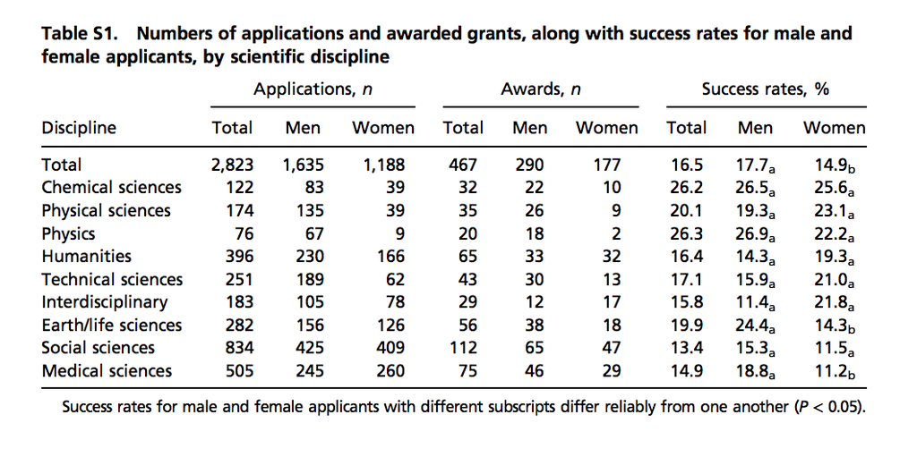

## Case study: extracting tables from PDF

- We could extract the numbers by hand, but this could lead to human error.
- Instead, we can try to wrangle the data using R.
- We start by downloading the pdf document, then importing into R:

## Case study: extracting tables from PDF

```r
library("pdftools")
temp_file <- tempfile()
url <- paste0("https://www.pnas.org/content/suppl/2015/09/16/",
              "1510159112.DCSupplemental/pnas.201510159SI.pdf")
download.file(url, temp_file)
txt <- pdf_text(temp_file)
file.remove(temp_file)
```

- If we examine the object text, we notice that it is a character vector with an entry for each page.

## Case study: extracting tables from PDF

- So we keep the page we want:

```r
raw_data_research_funding_rates <- txt[2]
```

- The steps above can actually be skipped because we include this raw data in the **dslabs** package as well:

```r
data("raw_data_research_funding_rates")
```

## Case study: extracting tables from PDF

- Examining the object `raw_data_research_funding_rates`.
- we see that it is a long string and each line on the page, including the table rows, are separated by the symbol for newline: `\n`.
- We therefore can create a list with the lines of the text as elements as follows:

```r
tab <- str_split(raw_data_research_funding_rates, "\n")
```

## Case study: extracting tables from PDF

- Because we start off with just one element in the string, we end up with a list with just one entry.

```r
tab <- tab[[1]]
```

- By examining `tab` we see that the information for the column names is the third and fourth entries:

## Case study: extracting tables from PDF

```r
the_names_1 <- tab[3]
the_names_2 <- tab[4]
```

- The first of these rows looks like this:

```
#>                                                       Applications, n
#>           Awards, n                      Success rates, %
```

## Case study: extracting tables from PDF

- We want to create one vector with one name for each column.
- Using some of the functions we have just learned, we do this.
- Let’s start with `the_names_1`, shown above.
- We want to remove the leading space and anything following the comma.
- We use regex for the latter.

## Case study: extracting tables from PDF

- Then we can obtain the elements by splitting strings separated by space.
- We want to split only when there are 2 or more spaces to avoid splitting `Success rates`.

## Case study: extracting tables from PDF

- So we use the regex `\\s{2,}`.

```r
the_names_1 <- the_names_1 |>
  str_trim() |>
  str_replace_all(",\\s.", "") |>
  str_split("\\s{2,}", simplify = TRUE)
the_names_1
```

```
#>      [,1]           [,2]     [,3]
#> [1,] "Applications" "Awards" "Success rates"
```

## Case study: extracting tables from PDF

- Now we will look at `the_names_2`:

```
#>                         Discipline              Total     Men      Women
#>   Total    Men       Women          Total    Men      Women
```

## Case study: extracting tables from PDF

- Here we want to trim the leading space and then split by space as we did for the first line:

```r
the_names_2 <- the_names_2 |>
  str_trim() |>
  str_split("\\s+", simplify = TRUE)
the_names_2
```

```
#>      [,1]         [,2]    [,3]  [,4]    [,5]    [,6]  [,7]    [,8]    [,9]
#> [1,] "Discipline" "Total" "Men" "Women" "Total" "Men" "Women" "Total" "Men"
#>      [,10]
#> [1,] "Women"
```

## Case study: extracting tables from PDF

- We can then join these to generate one name for each column:

```r
tmp_names <- str_c(rep(the_names_1, each = 3), the_names_2[-1], sep = "_")
the_names <- c(the_names_2[1], tmp_names) |>
  str_to_lower() |>
  str_replace_all("\\s", "_")
the_names
```

```
#>  [1] "discipline"          "applications_total"  "applications_men"
#>  [4] "applications_women"  "awards_total"        "awards_men"
#>  [7] "awards_women"        "success_rates_total" "success_rates_men"
#> [10] "success_rates_women"
```

## Case study: extracting tables from PDF

- Now we are ready to get the actual data.
- By examining the `tab` object, we notice that the information is in lines 6 through 14.

## Case study: extracting tables from PDF

- We can use `str_split` again to achieve our goal:

```r
new_research_funding_rates <- tab[6:14] |>
  str_trim() |>
  str_split("\\s{2,}", simplify = TRUE) |>
  data.frame() |>
  setNames(the_names) |>
  mutate_at(-1, parse_number)
new_research_funding_rates |> as_tibble()
```

```
#> # A tibble: 9 × 10
#>   discipline     applications_to… applications_men applications_wo… awards_total
#>   <chr>                     <dbl>            <dbl>            <dbl>        <dbl>
#> 1 Chemical scie…              122               83               39           32
#> 2 Physical scie…              174              135               39           35
#> 3 Physics                      76               67                9           20
#> 4 Humanities                  396              230              166           65
#> 5 Technical sci…              251              189               62           43
#> 6 Interdiscipli…              183              105               78           29
#> 7 Earth/life sc…              282              156              126           56
#> 8 Social scienc…              834              425              409          112
#> 9 Medical scien…              505              245              260           75
#> # … with 5 more variables: awards_men <dbl>, awards_women <dbl>,
#> #   success_rates_total <dbl>, success_rates_men <dbl>,
#> #   success_rates_women <dbl>
```

## Case study: extracting tables from PDF

- We can see that the objects are identical:

```r
identical(research_funding_rates, new_research_funding_rates)
```

```
#> [1] TRUE
```

## Recoding

- Another common operation involving strings is recoding the names of categorical variables.
- Let’s say you have really long names for your levels and you will be displaying them in plots, you might want to use shorter versions of these names.
- For example, in character vectors with country names, you might want to change “United States of America” to “USA” and “United Kingdom” to UK, and so on.
- We can do this with `case_when`, although the **tidyverse** offers an option that is specifically designed for this task: the `recode` function.
- Here is an example that shows how to rename countries with long names:

## Recoding

- Suppose we want to show life expectancy time series by country for the Caribbean:

```r
gapminder |>
  filter(region == "Caribbean") |>
  ggplot(aes(year, life_expectancy, color = country)) +
  geom_line()
```

## Recoding

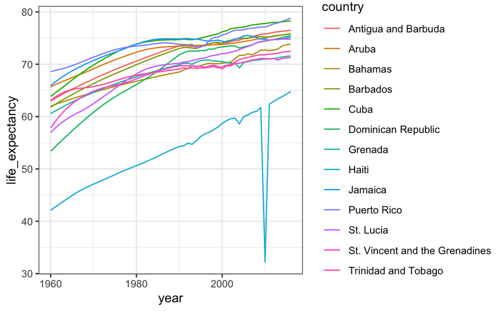

## Recoding

- The plot is what we want, but much of the space is wasted to accommodate some of the long country names.

```r
gapminder |>
  filter(region == "Caribbean") |>
  filter(str_length(country) >= 12) |>
  distinct(country)
```

```
#>                          country
#> 1            Antigua and Barbuda
#> 2             Dominican Republic
#> 3 St. Vincent and the Grenadines
#> 4            Trinidad and Tobago
```

## Recoding

- We have four countries with names longer than 12 characters.
- These names appear once for each year in the Gapminder dataset.
- Once we pick nicknames, we need to change them all consistently.

## Recoding

- The `recode` function can be used to do this:

```r
gapminder |> filter(region=="Caribbean") |>
  mutate(country = recode(country,
                          `Antigua and Barbuda` = "Barbuda",
                          `Dominican Republic` = "DR",
                          `St. Vincent and the Grenadines` = "St. Vincent",
                          `Trinidad and Tobago` = "Trinidad")) |>
  ggplot(aes(year, life_expectancy, color = country)) +
  geom_line()
```

## Recoding

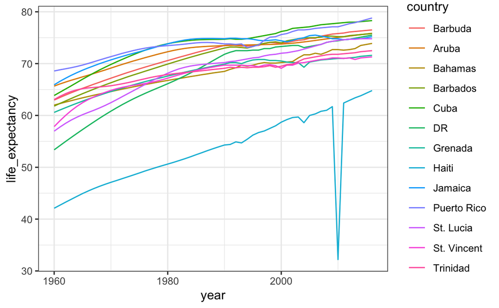

## Recoding

- There are other similar functions in other R packages, such as `recode_factor` and `fct_recoder` in the **forcats** package.